# FML_Assignment 4_Clustering

# after reviewing the clusters, K = 5 seems appropriate as per the grouping.

#using K=5 for the analysis

```r
k5=kmeans(dataset2, centers = 5, nstart = 25)
k5$size
```

```
## [1] 3 8 2 4 4
```

```r
k5$cluster
```

```
##  ABT  AGN  AHM  AZN  AVE  BAY  BMY CHTT  ELN  LLY  GSK  IVX  JNJ  MRX  MRK  NVS
##    2    3    2    2    4    1    2    1    4    2    5    1    5    4    5    2
##  PFE  PHA  SGP  WPI  WYE
##    5    3    2    4    2
```

```r
k5$centers
```

```
##    Market_Cap       Beta    PE_Ratio        ROE        ROA Asset_Turnover
## 1 -0.87051511  1.3409869 -0.05284434 -0.6184015 -1.1928478     -0.4612656
## 2 -0.03142211 -0.4360989 -0.31724852  0.1950459  0.4083915      0.1729746
## 3 -0.43925134 -0.4701800  2.70002464 -0.8349525 -0.9234951      0.2306328
## 4 -0.76022489  0.2796041 -0.47742380 -0.7438022 -0.8107428     -1.2684804
## 5  1.69558112 -0.1780563 -0.19845823  1.2349879  1.3503431      1.1531640
##      Leverage Rev_Growth Net_Profit_Margin
## 1  1.36644699 -0.6912914      -1.320000179
## 2 -0.27449312 -0.7041516       0.556954446
## 3 -0.14170336 -0.1168459      -1.416514761
## 4  0.06308085  1.5180158      -0.006893899
## 5 -0.46807818  0.4671788       0.591242521
```

```r
k5$withinss
```

```
## [1] 15.595925 21.879320  2.803505 12.791257  9.284424
```

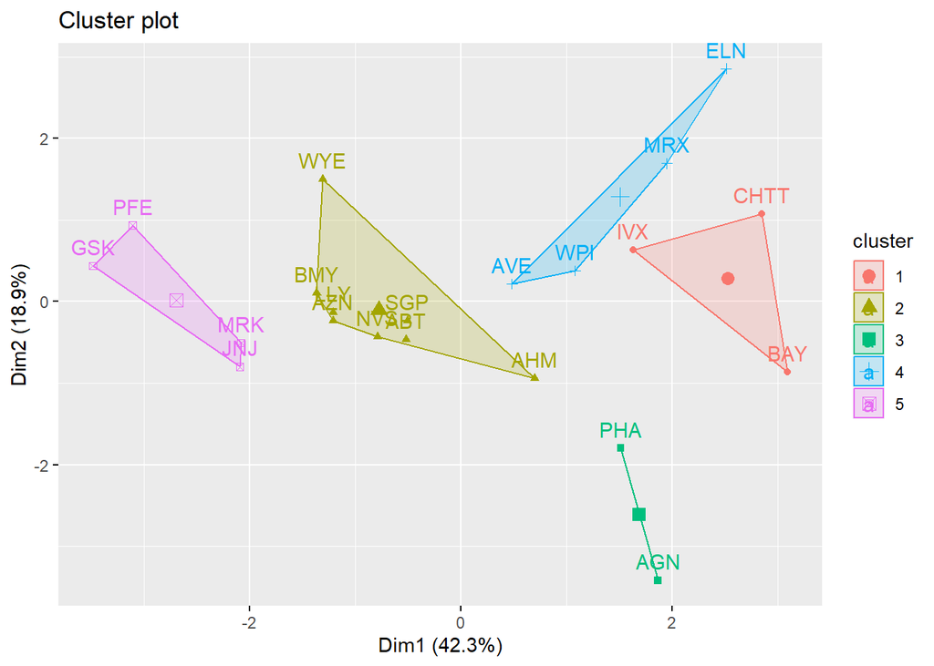

```r
fviz_cluster(k5, data = dataset2)
```

** Ques 2**

Interpret the clusters with respect to the numerical variables used in forming the clusters. Is there a pattern in the clusters with respect to the numerical variables (10 to 12)? (those not used in forming the clusters)

The data is segmented into five distinct clusters. Cluster #5 comprises four companies with both high net profit margins and substantial asset turnover, establishing them as credible institutions. In contrast, Cluster #1 consists of three companies characterized by a net profit margin of -1.32. These entities rely more on leveraging (1.36) and less on equities (-0.61).

#Plotting graphs of data grouped in clusters

```r
Centroid <- data.frame(k5$centers) %>% rowid_to_column() %>% gather('Columns', 'Centers', -1)
print(Centroid)
```

```
##    rowid           Columns      Centers
## 1      1        Market_Cap -0.870515113
## 2      2        Market_Cap -0.031422109
## 3      3        Market_Cap -0.439251341
## 4      4        Market_Cap -0.760224892
## 5      5        Market_Cap  1.695581115
## 6      1              Beta  1.340986857
## 7      2              Beta -0.436098941
## 8      3              Beta -0.470180039
## 9      4              Beta  0.279604106
## 10     5              Beta -0.178056346
## 11     1          PE_Ratio -0.052844340
## 12     2          PE_Ratio -0.317248516
## 13     3          PE_Ratio  2.700024643
## 14     4          PE_Ratio -0.477423799
```

[output cut: 31 more lines]

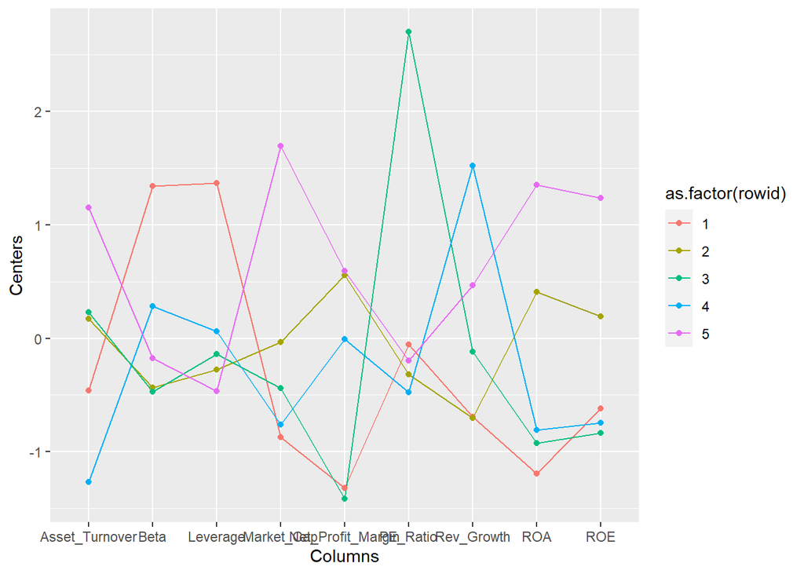

```r
ggplot(Centroid, aes(x = Columns, y = Centers, color = as.factor(rowid))) + geom_line(aes(group = as.factor(rowid))) + geom_point()
```

Ques - Is there a pattern in the clusters with respect to the numerical variables (10 to 12)?